# Male and female germline peaks

Miriam Kretschmer

5/9/2022

```r
#setwd("/mnt/bohacek/kathi/miriam/accessibilty_sperm_embryo")

suppressPackageStartupMessages(library(magrittr))
suppressPackageStartupMessages(library(universalmotif))
suppressPackageStartupMessages(library(BSgenome))
suppressPackageStartupMessages(library(memes))
suppressPackageStartupMessages(library(ggbio))
suppressPackageStartupMessages(library(Rsamtools))
suppressPackageStartupMessages(library(GenomicRanges))
suppressPackageStartupMessages(library(EnrichedHeatmap))
suppressPackageStartupMessages(library(GenomicAlignments))
suppressPackageStartupMessages(library(grid))
suppressPackageStartupMessages(library(epiwraps))
```

# 1 Introduction

Using the samples with good quality as assessed in “Sperm and embryo QC.Rmd” to produce consensus peaks for downstream analysis. Further, peaks will be filtered to extract all peaks that contain at least one GRE motif. The glucocorticoid receptor response element, in short GRE, is the DNA sequence to which the glucocorticoid receptor can bind directly to regulate gene expression. Previous results by Pierre-Luc Germain have shown that the GRE is the most enriched motif in accessible sites in sperm.

# 2 GRE motif

```r
query(ah, pattern=c("GRCm39", "dna_sm"))$ah_id[[1]]
```

```
## [1] "AH90965"
```

```r
genome <- ah[["AH90965"]]
```

```
## loading from cache
```

```r
GRE_motif <- MotifDb::MotifDb %>%
  MotifDb::query("GRE") %>%
  universalmotif::convert_motifs() %>%
  .[[1]]
```

```
## See system.file("LICENSE", package="MotifDb") for use restrictions.
```

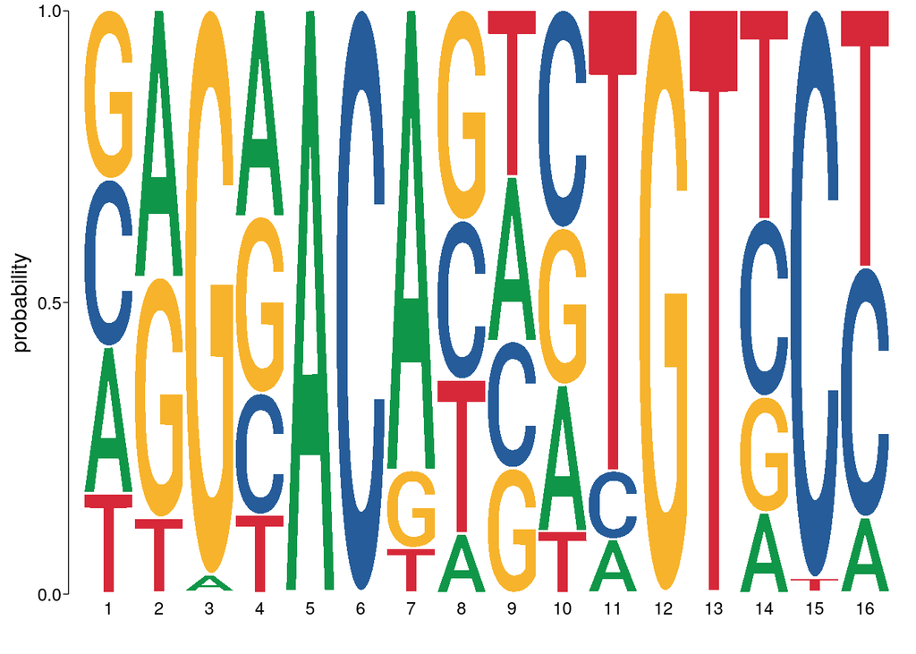

Figure 2.1: GRE motif

```r
view_motifs(GRE_motif, use.type = "PPM")
```

# 3 Generating consensus peaks

## 3.1 Female germline

### 3.1.1 MIIoocytes

**Peaks containing GRE**

```r
peaks <- import("/mnt/bohacek/kathi/fromLiterature/ATAC_PE/peaks/ATAC_PRJNA480448_MIIoocyte_GSM3262863_peaks.broadPeak")
peak_seqs <- get_sequence(peaks, genome)
fimo <- runFimo(peak_seqs, GRE_motif, meme_path = "/common/meme/bin")
GRE_peaks <- peaks[overlapsAny(peaks, fimo)]
saveRDS(GRE_peaks, "rds_saves/peaks/peaks_with_GRE_mIIoocytes.rds")
```

```r
length(fimo)
sum(overlapsAny(peaks, fimo))
```

There are 1755 GRE sites in all peaks. There are 936 peaks that contain at least one GRE site.

```r
tracks <- c(
  mIIoocyte1="/mnt/bohacek/kathi/fromLiterature/ATAC_PE/tracks/ATAC_PRJNA480448_MIIoocyte_GSM3262863.bw",
  mIIoocyte2="/mnt/bohacek/kathi/fromLiterature/ATAC_PE/tracks/ATAC_PRJNA480448_MIIoocyte_GSM3262864.bw"
)
m <- signal2Matrix(tracks, GRE_peaks, w = 20, BPPARAM = 2)
```

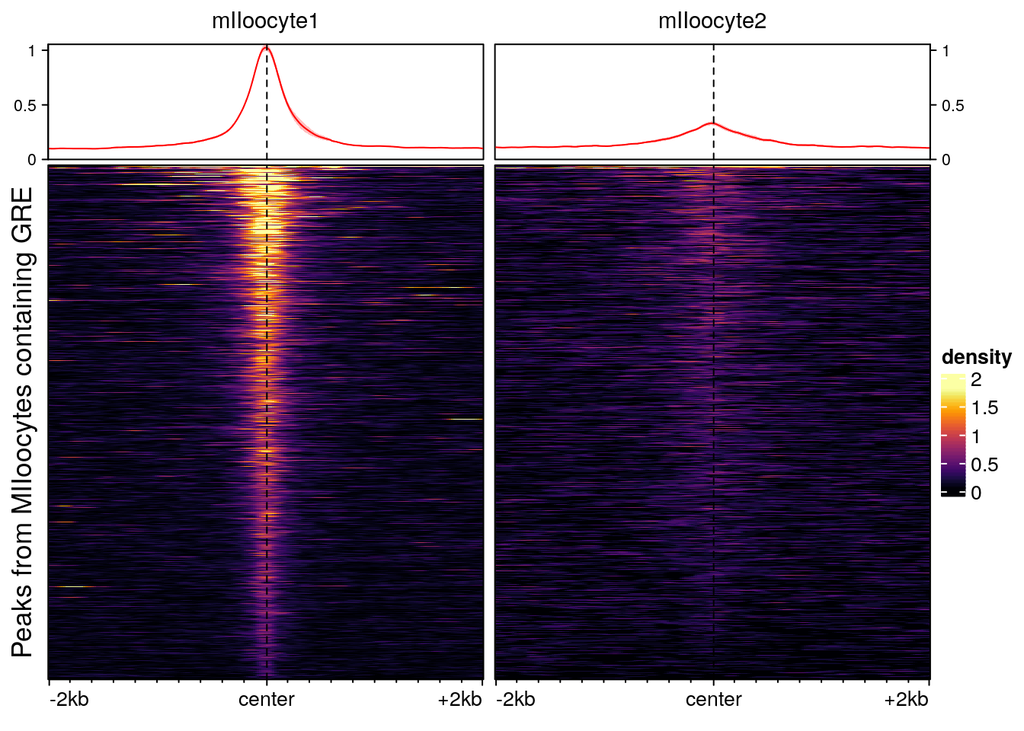

Figure 3.1: Accessibility of MII oocytes at peak regions containing GRE

```r
plotEnrichedHeatmaps(m, row_title="Peaks from MIIoocytes containing GRE", trim = 0.99)
```

### 3.1.2 GV oocytes

**Consensus peaks**

```r
peaks1 <- import("/mnt/bohacek/kathi/fromLiterature/DNAse/peaks/DNAse_PRJNA308221_OocyteGV_GSM2183029_peaks.narrowPeak")
peaks2 <- import("/mnt/bohacek/kathi/fromLiterature/DNAse/peaks/DNAse_PRJNA308221_OocyteGV_GSM2183030_peaks.narrowPeak")


allpeaks <- c(peaks1, peaks2)
peaks <- reduce(allpeaks, with.revmap=TRUE)
saveRDS(peaks, "rds_saves/peaks/consensus.peaks_GVoocytes.rds")
```

**Peaks containing GRE**

```r
peak_seqs <- get_sequence(peaks, genome)
fimo <- runFimo(peak_seqs, GRE_motif, meme_path = "/common/meme/bin")
GRE_peaks <- peaks[overlapsAny(peaks, fimo)]
saveRDS(GRE_peaks, "rds_saves/peaks/peaks_with_GRE_GVoocytes.rds")
length(fimo)
sum(overlapsAny(peaks, fimo))
```

There are 74 GRE sites in all peaks. There are 40 peaks that contain at least one GRE site.

```r
tracks <- c(
  GVoocyte1="/mnt/bohacek/kathi/fromLiterature/DNAse/tracks/DNAse_PRJNA308221_OocyteGV_GSM2183029.bw",
  GVoocyte2="/mnt/bohacek/kathi/fromLiterature/DNAse/tracks/DNAse_PRJNA308221_OocyteGV_GSM2183030.bw"
)
m <- signal2Matrix(tracks, GRE_peaks, w = 20, BPPARAM = 2)
```

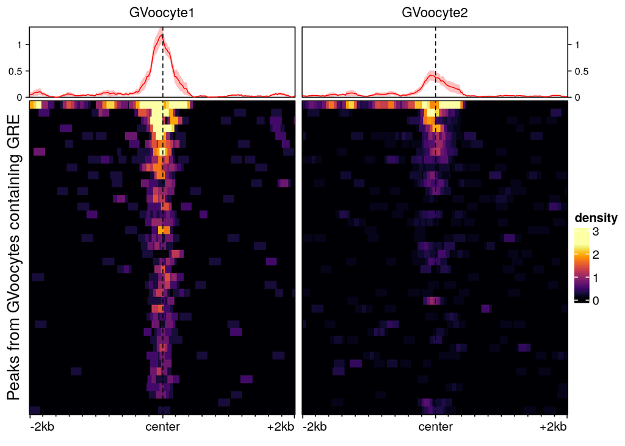

Figure 3.2: Accessibility of GV oocytes at peak regions containing GRE

```r
plotEnrichedHeatmaps(m, row_title="Peaks from GVoocytes containing GRE", trim = 0.99)
```

## 3.2 Male germline

### 3.2.1 Mature sperm

**Consensus peaks**

```r
peaks1 <- import("/mnt/bohacek/kathi/fromLiterature/ATAC_PE/peaks/ATAC_PRJNA480448_Sperm_GSM3262855_peaks.broadPeak")
peaks2 <- import("/mnt/bohacek/kathi/fromLiterature/ATAC_PE/peaks/ATAC_PRJNA480448_Sperm_GSM3262856_peaks.broadPeak")
peaks3 <- import("/mnt/bohacek/kathi/fromLiterature/ATAC_PE/peaks/ATAC_PRJNA315208_Sperm_GSM2088378_peaks.broadPeak")


allpeaks <- c(peaks1, peaks2, peaks3)
peaks <- reduce(allpeaks, with.revmap=TRUE)
peaks <- peaks[lengths(peaks$revmap)>=2]
length(peaks) #33883
saveRDS(peaks, "rds_saves/peaks/consensus.peaks_sperm.rds")
```

**Peaks containing GRE**

```r
peak_seqs <- get_sequence(peaks, genome)
fimo <- runFimo(peak_seqs, GRE_motif, meme_path = "/common/meme/bin")
GRE_peaks <- peaks[overlapsAny(peaks, fimo)]
saveRDS(GRE_peaks, "rds_saves/peaks/peaks_with_GRE_sperm.rds")
length(fimo)
sum(overlapsAny(peaks, fimo))
```

There are 19167 GRE sites in all peaks. There are 8908 peaks that contain at least one GRE site.

```r
tracks <- c(
  sperm1="/mnt/bohacek/kathi/fromLiterature/ATAC_PE/tracks/ATAC_PRJNA480448_Sperm_GSM3262855.bw",
  sperm2="/mnt/bohacek/kathi/fromLiterature/ATAC_PE/tracks/ATAC_PRJNA480448_Sperm_GSM3262856.bw",
  sperm3="/mnt/bohacek/kathi/fromLiterature/ATAC_PE/tracks/ATAC_PRJNA315208_Sperm_GSM2088378.bw"
)
m <- signal2Matrix(tracks, GRE_peaks, w = 20, BPPARAM = 2)
```

[output not shown]

[output not shown]

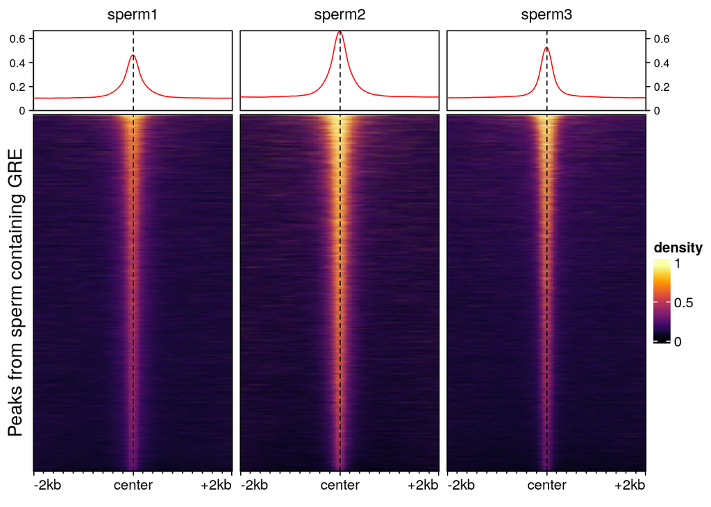

Figure 3.3: Accessibility of sperm at peak regions containing GRE

```r
plotEnrichedHeatmaps(m, row_title="Peaks from sperm containing GRE", trim = 0.99)
```

### 3.2.2 Round spermatids

**Consensus peaks**

```r
peaks1 <- import("/mnt/bohacek/kathi/fromLiterature/ATAC_SE/peaks/ATACse_PRJNA399533_RoundSpermatides_GSM2751133_peaks.broadPeak")
peaks2 <- import("/mnt/bohacek/kathi/fromLiterature/ATAC_SE/peaks/ATACse_PRJNA399533_RoundSpermatides_GSM2751134_peaks.broadPeak")

allpeaks <- c(peaks1, peaks2)
peaks <- reduce(allpeaks, with.revmap=TRUE)
peaks <- peaks[lengths(peaks$revmap)>=2]
length(peaks) #20682
saveRDS(peaks, "rds_saves/peaks/consensus.peaks_rs.rds")
```

**Peaks containing GRE**

```r
peak_seqs <- get_sequence(peaks, genome)
fimo <- runFimo(peak_seqs, GRE_motif, meme_path = "/common/meme/bin")
GRE_peaks <- peaks[overlapsAny(peaks, fimo)]
saveRDS(GRE_peaks, "rds_saves/peaks/peaks_with_GRE_rs.rds")
length(fimo)
sum(overlapsAny(peaks, fimo))
```

There are 4073 GRE sites in all peaks. There are 1702 peaks that contain at least one GRE site.

```r
tracks <- c(
  round_spermatids1="/mnt/bohacek/kathi/fromLiterature/ATAC_SE/tracks/ATACse_PRJNA399533_RoundSpermatides_GSM2751133.bw",
  round_spermatids2="/mnt/bohacek/kathi/fromLiterature/ATAC_SE/tracks/ATACse_PRJNA399533_RoundSpermatides_GSM2751134.bw"
)
m <- signal2Matrix(tracks, GRE_peaks, w = 20, BPPARAM = 2)
```

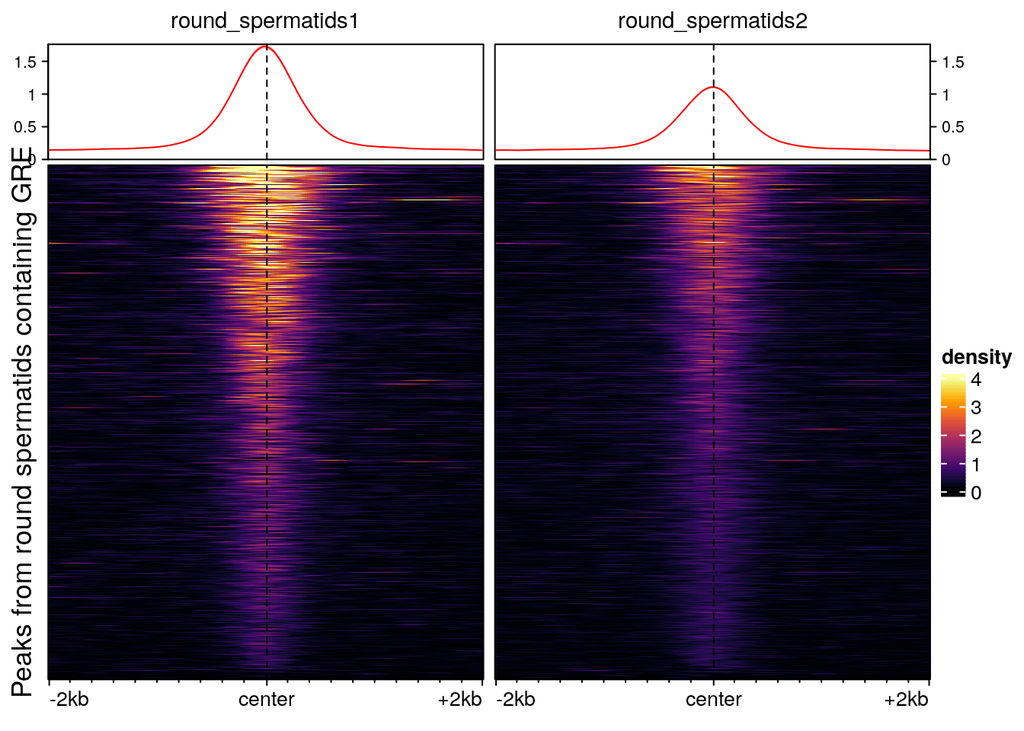

Figure 3.4: Accessibility of round spermatids at peak regions containing GRE

```r
plotEnrichedHeatmaps(m, row_title="Peaks from round spermatids containing GRE", trim = 0.99)
```

### 3.2.3 Pachytene spermatocytes

**Consensus peaks**

```r
peaks1 <- import("/mnt/bohacek/kathi/fromLiterature/ATAC_SE/peaks/ATACse_PRJNA399533_PachytenSpermatocytes_GSM2751129_peaks.broadPeak")
peaks2 <- import("/mnt/bohacek/kathi/fromLiterature/ATAC_SE/peaks/ATACse_PRJNA399533_PachytenSpermatocytes_GSM2751130_peaks.broadPeak")

allpeaks <- c(peaks1, peaks2)
peaks <- reduce(allpeaks, with.revmap=TRUE)
peaks <- peaks[lengths(peaks$revmap)>=2]
length(peaks) #21577
saveRDS(peaks, "rds_saves/peaks/consensus.peaks_ps.rds")
```

**Peaks containing GRE**

```r
peak_seqs <- get_sequence(peaks, genome)
fimo <- runFimo(peak_seqs, GRE_motif, meme_path = "/common/meme/bin")
GRE_peaks <- peaks[overlapsAny(peaks, fimo)]
saveRDS(GRE_peaks, "rds_saves/peaks/peaks_with_GRE_ps.rds")
length(fimo)
sum(overlapsAny(peaks, fimo))
```

There are 4124 GRE sites in all peaks. There are 1899 peaks that contain at least one GRE site.

```r
tracks <- c(
  "pachytene_spermatocytes1"="/mnt/bohacek/kathi/fromLiterature/ATAC_SE/tracks/ATACse_PRJNA399533_PachytenSpermatocytes_GSM2751129.bw",
  "pachytene_spermatocytes2"="/mnt/bohacek/kathi/fromLiterature/ATAC_SE/tracks/ATACse_PRJNA399533_PachytenSpermatocytes_GSM2751130.bw"
)
m <- signal2Matrix(tracks, GRE_peaks, w = 20, BPPARAM = 2)
```

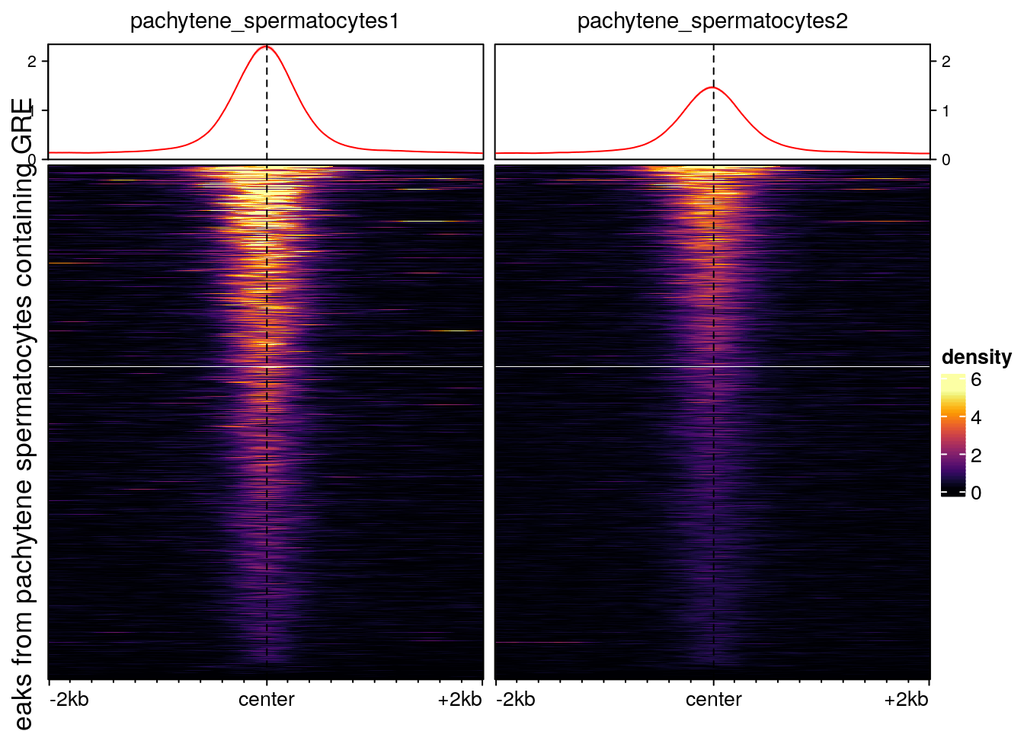

Figure 3.5: Accessibility of pachytene spermatocytes at peak regions containing GRE

```r
plotEnrichedHeatmaps(m, row_title="Peaks from pachytene spermatocytes containing GRE", trim = 0.99)
```

### 3.2.4 Differentiating spermatogonia

**Consensus peaks**

```r
peaks1 <- import("/mnt/bohacek/kathi/fromLiterature/ATAC_SE/peaks/ATACse_PRJNA399533_cKitposSpermatogonia_GSM2751125_peaks.broadPeak")
peaks2 <- import("/mnt/bohacek/kathi/fromLiterature/ATAC_SE/peaks/ATACse_PRJNA399533_cKitposSpermatogonia_GSM2751126_peaks.broadPeak")

allpeaks <- c(peaks1, peaks2)
peaks <- reduce(allpeaks, with.revmap=TRUE)
peaks <- peaks[lengths(peaks$revmap)>=2]
length(peaks) #29906
saveRDS(peaks, "rds_saves/peaks/consensus.peaks_ds.rds")
```

**Peaks containing GRE**

```r
peak_seqs <- get_sequence(peaks, genome)
fimo <- runFimo(peak_seqs, GRE_motif, meme_path = "/common/meme/bin")
GRE_peaks <- peaks[overlapsAny(peaks, fimo)]
saveRDS(GRE_peaks, "rds_saves/peaks/peaks_with_GRE_ds.rds")
length(fimo)
sum(overlapsAny(peaks, fimo))
```

There are 7352 GRE sites in all peaks. There are 3587 peaks that contain at least one GRE site.

```r
tracks <- c(
  "differentiating_spermatogonia1"="/mnt/bohacek/kathi/fromLiterature/ATAC_SE/tracks/ATACse_PRJNA399533_cKitposSpermatogonia_GSM2751125.bw",
  "differentiating_spermatogonia2"="/mnt/bohacek/kathi/fromLiterature/ATAC_SE/tracks/ATACse_PRJNA399533_cKitposSpermatogonia_GSM2751126.bw"
)
m <- signal2Matrix(tracks, GRE_peaks, w = 20, BPPARAM = 2)
```

[output not shown]

[output not shown]

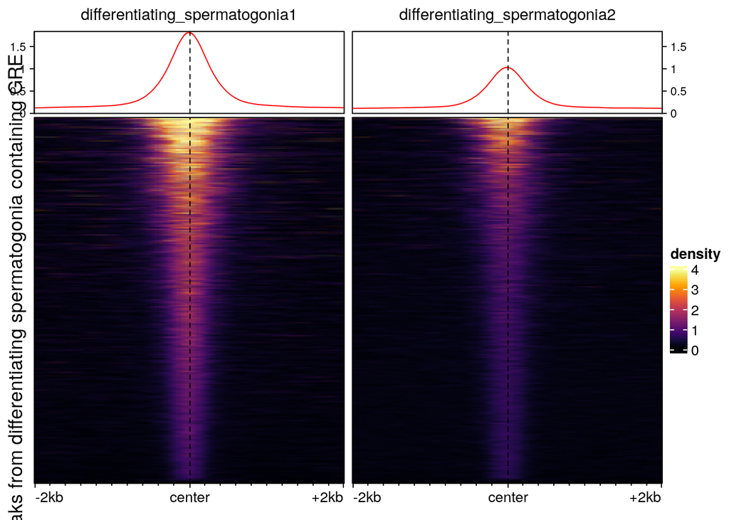

Figure 3.6: Accessibility of differentiating spermatogonia at peak regions containing GRE

```r
plotEnrichedHeatmaps(m, row_title="Peaks from differentiating spermatogonia containing GRE", trim = 0.99)
```

### 3.2.5 Undifferentiated spermatogonia

**Consensus peaks**

```r
peaks1 <- import("/mnt/bohacek/kathi/fromLiterature/ATAC_SE/peaks/ATACse_PRJNA399533_Thy1posSpermatogonia_GSM2751121_peaks.broadPeak")
peaks2 <- import("/mnt/bohacek/kathi/fromLiterature/ATAC_SE/peaks/ATACse_PRJNA399533_Thy1posSpermatogonia_GSM2751122_peaks.broadPeak")

allpeaks <- c(peaks1, peaks2)
peaks <- reduce(allpeaks, with.revmap=TRUE)
peaks <- peaks[lengths(peaks$revmap)>=2]
length(peaks) #56774
saveRDS(peaks, "rds_saves/peaks/consensus.peaks_uds.rds")
```

**Peaks containing GRE**

```r
peak_seqs <- get_sequence(peaks, genome)
fimo <- runFimo(peak_seqs, GRE_motif, meme_path = "/common/meme/bin")
GRE_peaks <- peaks[overlapsAny(peaks, fimo)]
saveRDS(GRE_peaks, "rds_saves/peaks/peaks_with_GRE_uds.rds")
length(fimo)
sum(overlapsAny(peaks, fimo))
```

There are 18231 GRE sites in all peaks. There are 8608 peaks that contain at least one GRE site.

```r
tracks <- c(
  "undifferentiated_spermatogonia1"="/mnt/bohacek/kathi/fromLiterature/ATAC_SE/tracks/ATACse_PRJNA399533_Thy1posSpermatogonia_GSM2751121.bw",
  "undifferentiated_spermatogonia2"="/mnt/bohacek/kathi/fromLiterature/ATAC_SE/tracks/ATACse_PRJNA399533_Thy1posSpermatogonia_GSM2751122.bw"
)
m <- signal2Matrix(tracks, GRE_peaks, w = 20, BPPARAM = 2)
```

[output not shown]

[output not shown]

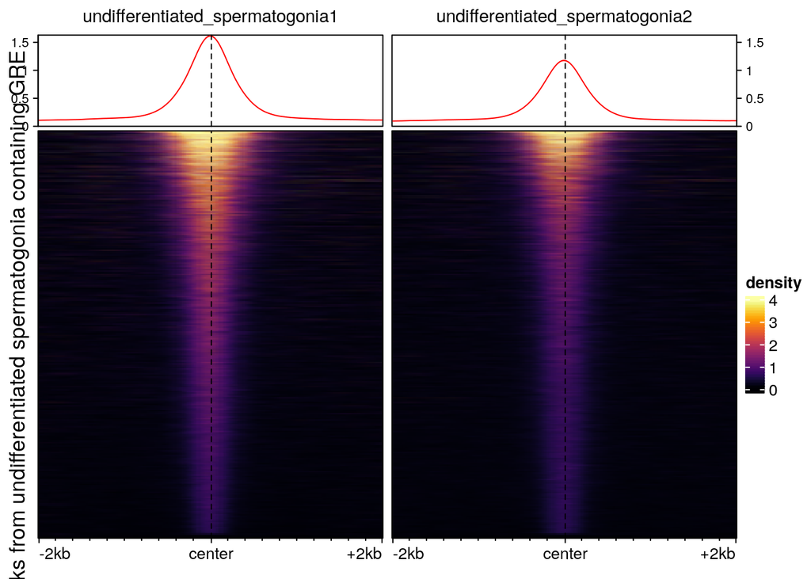

Figure 3.7: Accessibility of undifferentiated spermatogonia at peak regions containing GRE

```r
plotEnrichedHeatmaps(m, row_title="Peaks from undifferentiated spermatogonia containing GRE", trim = 0.99)
```

# 4 References